# A counterfactual dataset

Frame Detection

Chung-hong Chan

GESIS

2023-05-13

## Title

Frame? Kein Thema! Die Validität der induktiven Frame-Erkennung in Texten mit mehreren Themen

A counterfactual dataset for evaluating frame detection methods in multi-topical news content

- Chung-hong Chan
- Rainer Freudenthaler
- Philipp Müller

## Acknowledgement

The authors would like to thank the Open Science Office, University of Mannheim for the financial support of this project.

More infomation: https://www.uni-mannheim.de/open-science/open-science-office/

Also Valerie Hase (LMU Munich), and the following student helpers: Filippo Borsato, Hannah Erb, Hyosun Jang, Fatih Ozhasar, Zeynep Özgülec, and Jonathan Vincent.

## The current state of framing literature

“Some studies employ the concept only in a metaphoric sense, whereas others reduce frames to story topics, attributes, or issue position”

Carragee & Roefs (2004)

“(Framing researchers) give an obligatory nod to the literature before proceeding to do whatever they were going to do in the first place.”

Reese (2007)

## What’s a frame?

**Entmanian Frame:** “Select some aspects of a perceived reality and make them more salient in a communicating text, in such a way as to promote a particular problem definition, causal interpretation, moral evaluation, and/or treatment recommendation for the item described.”

Entman (1993)

**Chan’s restatement:** Frame is the result of an act of **selecting** certain aspects of a perceived reality by a communicator, whose **intention** is to promote a particular problem definition, causal interpretation, moral evalution, and/or treatment recommendation.

## Generic frames

“**transcend** thematic limitations and can be identified in relation to different topics, some even over time and in different cultural contexts”

de Vreese (2005)

## Raison d’être: Factual data

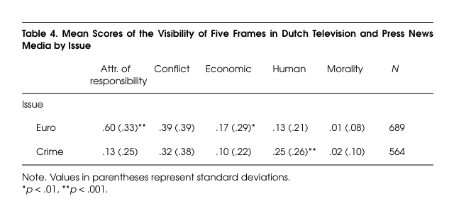

Semetko & Valkenburg (2000)

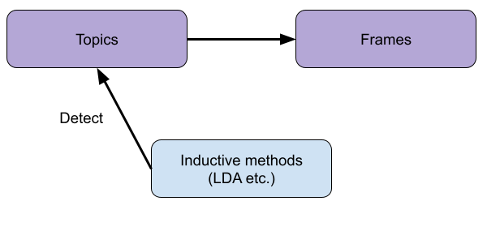

## Raison d’être: Counterfactual data

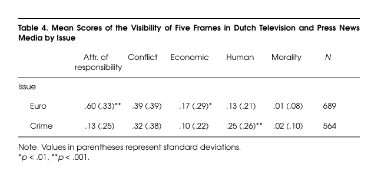

Semetko & Valkenburg (2000)

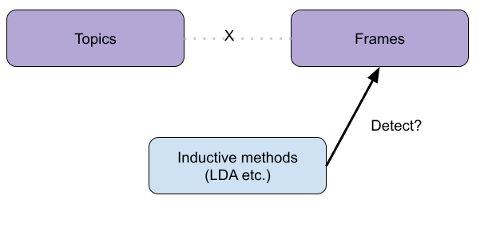

## Generation of counterfactual data

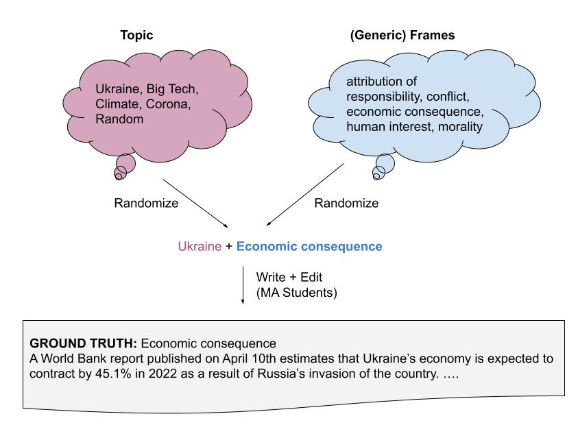

Topic and Communicative intention are independent and known

## Distribution

| topic | Conflict | Conseq. | Hum. Int. | Morality | Resp. |
| --- | --- | --- | --- | --- | --- |
| Climate | 6 | 1 | 7 | 2 | 4 |
| Corona | 5 | 3 | 4 | 5 | 3 |
| Joker | 1 | 5 | 5 | 6 | 3 |
| Tech | 4 | 7 | 2 | 3 | 4 |
| Ukraine | 5 | 6 | 2 | 2 | 5 |

## Example: Evaluation I

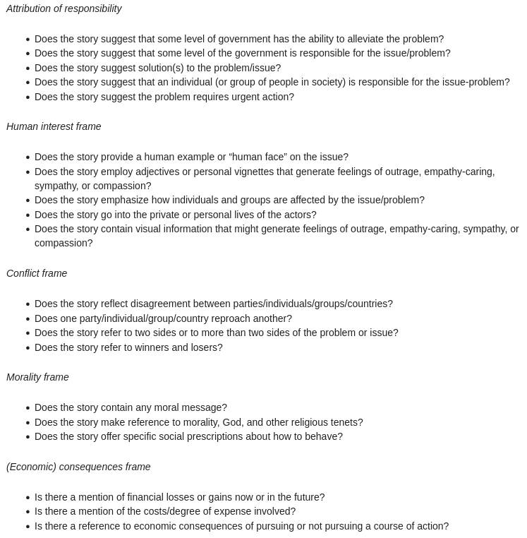

Semetko & Valkenburg (2000)

“Gold Standard”

By two trained students; and two experts with PhD in communication

## Multiverse analysis (Preregistered)

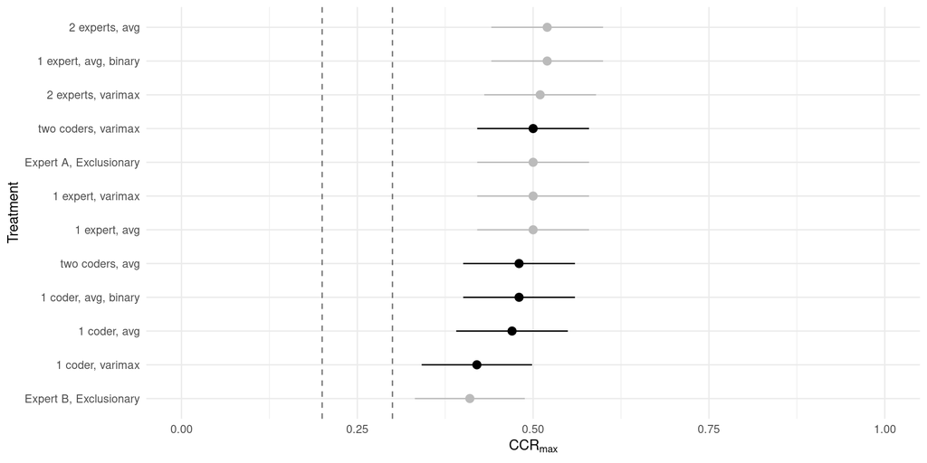

Pipal, Song, Boomgaarden (2022)

## Example: Evaluation II

**Inductive methods**

- K-means with TFIDF
- PCA with TF-IDF
- LDA
- STM
- ANTMN

(Burscher et al., 2016; Greussing & Boomgaarden, 2017; DiMaggio et al., 2013; Nicholls & Culpepper, 2021; Walter & Ophir, 2019)

**Semi-supervised methods**

- Seeded-LDA
- keyATM

(Watanabe & Zhou, 2020; Eshima et al., 2020)

Keywords from two journalism researchers

k = 5

## Multiverse analysis (an example)

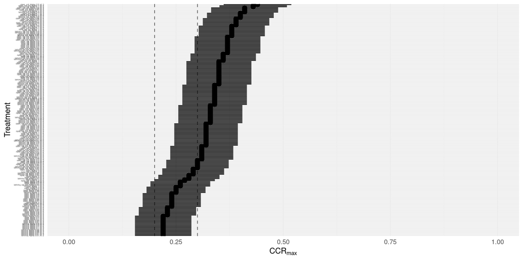

## Method comparison

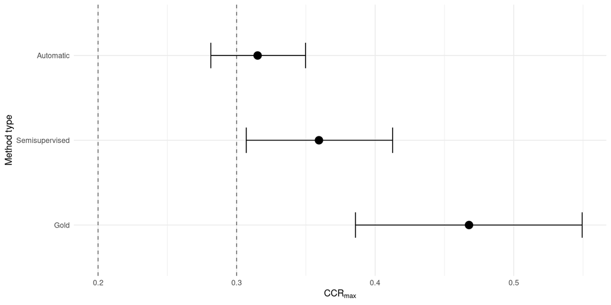

## Contributions

- A counterfactual data for benchmarking frame detection methods
- Methodological implications of the current benchmark: read our paper

[figure not shown]

@chainsawriot@emac.ch